# Analyse Blauwgrasland Rome

C.H. van Immerzeel

19-5-2020

### Opmerkingen vooraf.

- Gebruik 64-bit versie van R (versienummer >=R-4.0.0);
- Deze analyse maakt gebruik van de gegevens in de R-package in GitHub https://github.com/KVIsweco/DataBlauwgraslandRome;
- Figuren en raster layers worden weggeschreven in de `home` directory.

### Het huidige oppervlak blauwgrasland

Het huidige oppervlak blauwgrasland is 10.11 ha (7.5%)

### Splits de gegevens voor het trainen en het testen van het model.

Gebruik de helft van de gegevens voor het trainen van het model en de andere helft voor het testen van het model.

```r
df <- create_df()
ok <- complete.cases(df)
df <- df[ok, ]
set.seed(5)
inTrain <-
  caret::createDataPartition(y = df$Veg, p = 0.5, list = FALSE)
training <- df[inTrain, ]
testing <- df[-inTrain, ]
```

### Bepaal passende waarde van de modelparameters `.mtry` en `.ntree`.

`.mtry` is het aantal parameters dat wordt gebruikt bij de bouw van iedere beslisboom. `.ntree` is het aantal beslisbomen dat wordt gebruikt in het model.

```r
tunegrid <- expand.grid(.mtry=c(1:15))
control <- caret::trainControl(method="repeatedcv", number=10, repeats=5, search="grid")
modellist <- list()
for (ntree in c(500, 1000, 1500, 2000, 2500)) {
  set.seed(6)
  fit <-
      caret::train(
      Veg ~ .,
      data = training,
      method = "rf",
      tuneGrid = tunegrid,
      trControl = control,
      ntree = ntree
    )
  key <- toString(ntree)
  modellist[[key]] <- fit
}
```

### Vergelijk de resultaten van de modellen.

```r
results <- caret::resamples(modellist)
summary(results)
```

```
##
## Call:
## summary.resamples(object = results)
##
## Models: 500, 1000, 1500, 2000, 2500
## Number of resamples: 50
##
## Accuracy
##           Min.   1st Qu.    Median      Mean   3rd Qu.      Max. NA's
## 500  0.9471923 0.9531294 0.9553654 0.9552712 0.9568573 0.9624535    0
## 1000 0.9471923 0.9532180 0.9553737 0.9552042 0.9568573 0.9624535    0
## 1500 0.9483079 0.9531250 0.9550102 0.9551744 0.9571362 0.9628253    0
## 2000 0.9471923 0.9531424 0.9550019 0.9551670 0.9567724 0.9624535    0
## 2500 0.9471923 0.9531250 0.9550102 0.9551298 0.9568573 0.9628253    0
##
## Kappa
##           Min.   1st Qu.    Median      Mean   3rd Qu.      Max. NA's
## 500  0.5372547 0.6002021 0.6132300 0.6147436 0.6300999 0.6789817    0
## 1000 0.5372547 0.6011374 0.6133619 0.6139992 0.6317596 0.6789817    0
## 1500 0.5406147 0.5916984 0.6111201 0.6109989 0.6327569 0.6812925    0
## 2000 0.5320257 0.5985003 0.6165633 0.6140252 0.6305040 0.6807200    0
## 2500 0.5293667 0.5893946 0.6100767 0.6106803 0.6282965 0.6830230    0
```

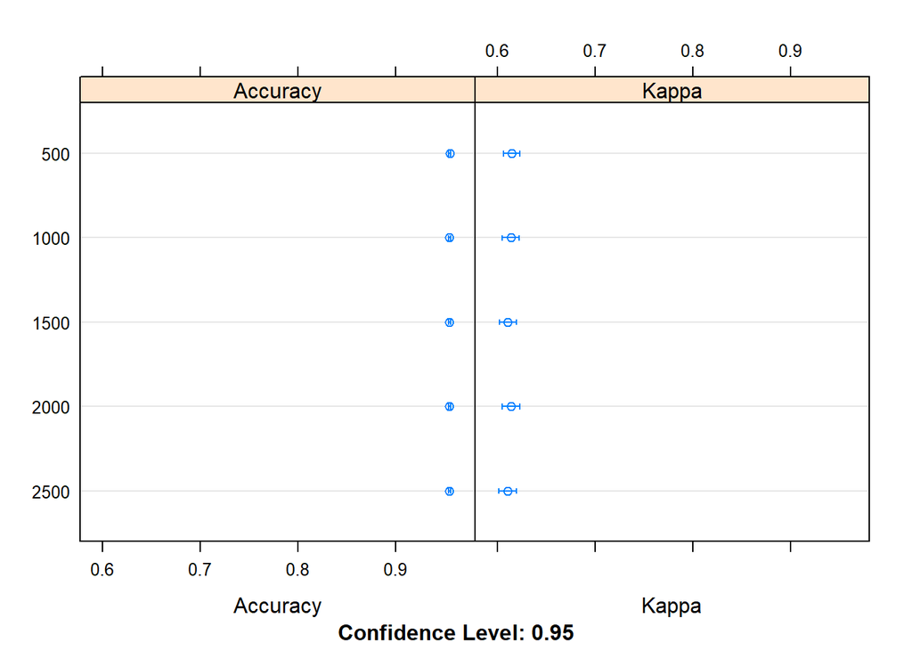

```r
dotplot(results)
```

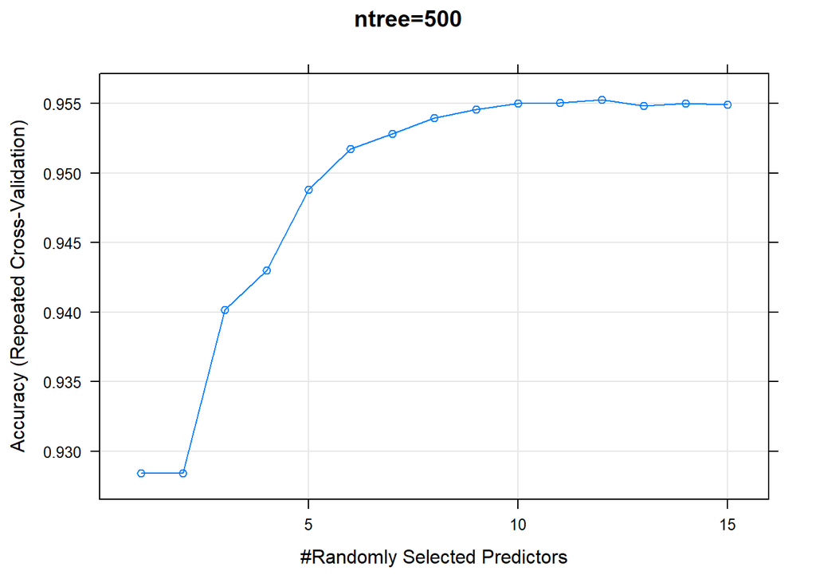

```r
plot(modellist["500"][[1]],main="ntree=500")
```

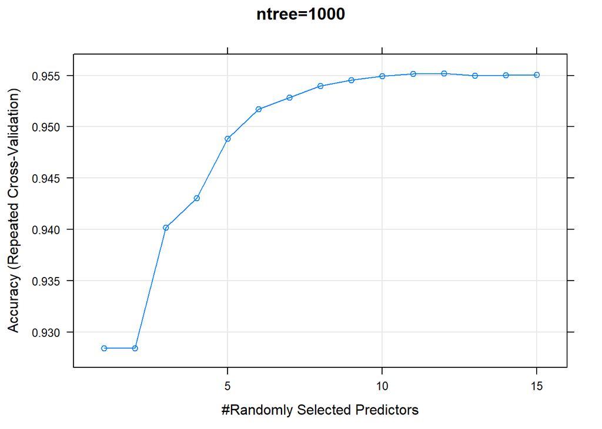

```r
plot(modellist["1000"][[1]],main="ntree=1000")
```

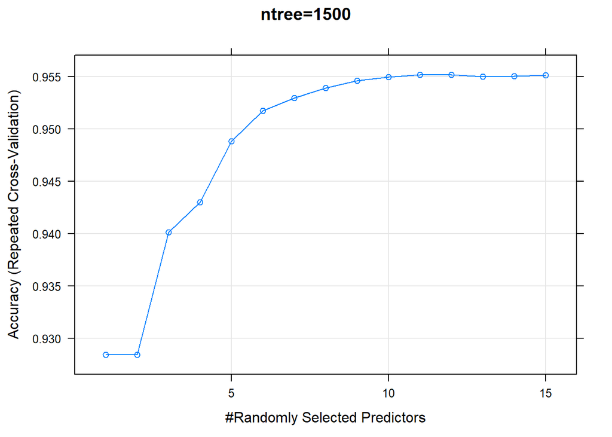

```r
plot(modellist["1500"][[1]],main="ntree=1500")
```

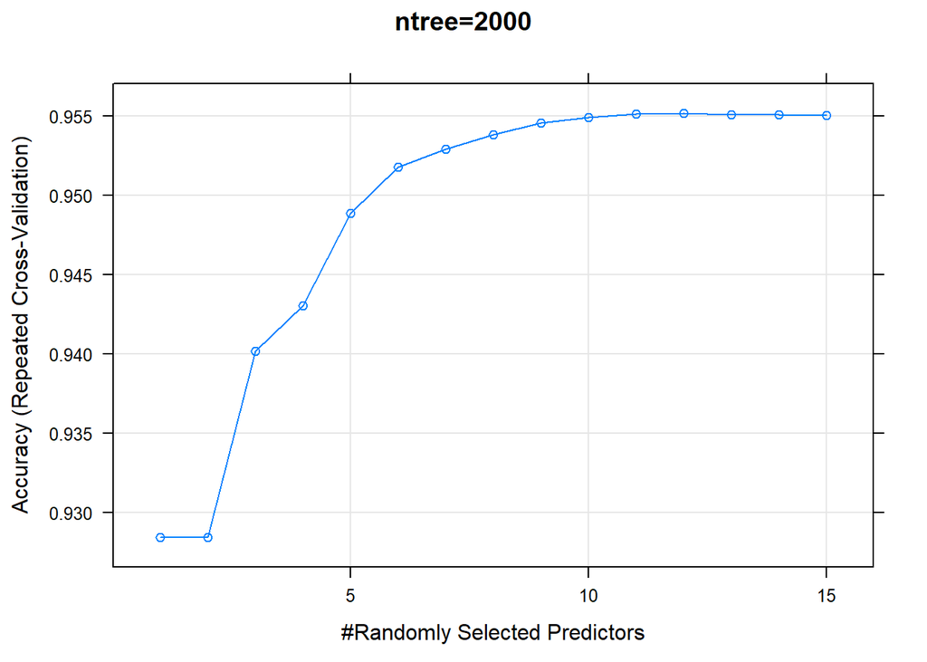

```r
plot(modellist["2000"][[1]],main="ntree=2000")
```

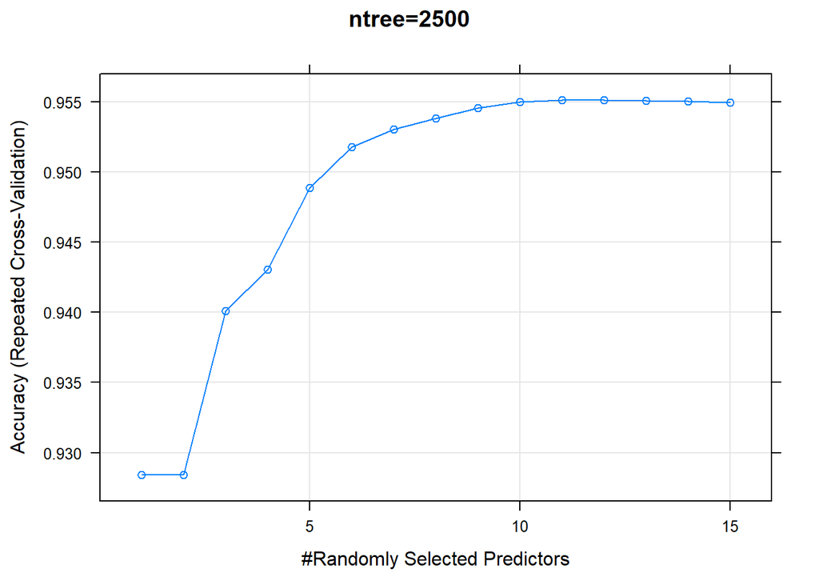

```r
plot(modellist["2500"][[1]],main="ntree=2500")
```

### Zoek het eenvoudigste model (mtry) dat nog voldoet.

Het eenvoudigste model dat nog voldoet (10% verlies van performance)

Gebruik daarbij `.ntree=500` (op basis van de bovenstaande plots). Verwijder niet gebruikte modellen.

```r
.ntree <- 500
sel_modelnr <-
  caret::tolerance(
    modellist[as.character(.ntree)][[1]]$results,
    metric = "Kappa",
    tol = 10,
    maximize = TRUE
  )
mtry <- modellist[as.character(.ntree)][[1]]$results$mtry[sel_modelnr]
modFit <- modellist[as.character(.ntree)][[1]]
rm(modellist)
```

Voor het gekozen model geldt `mtry=: 7`.

### Plot variable importance van het gekozen model.

De grafiek wordt weggeschreven naar de ‘home’ directory als `variable_importance.png`.

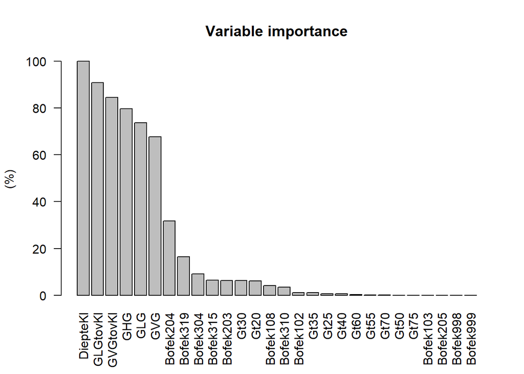

### Controleer het functioneren van het model met behulp van de test dataset.

Maak daarvoor de ‘confusion matrix’.

```r
cm  <-
  confusionMatrix(
    data = stats::predict( modFit, testing ),
    reference = testing$Veg,
    positive = levels(testing$Veg)[2]
  )
cm
```

```
## Confusion Matrix and Statistics
##
##           Reference
## Prediction     0     1
##          0 24768   559
##          1   199  1366
##
##                Accuracy : 0.9718
##                  95% CI : (0.9698, 0.9738)
##     No Information Rate : 0.9284
##     P-Value [Acc > NIR] : < 2.2e-16
##
##                   Kappa : 0.7679
##
##  Mcnemar's Test P-Value : < 2.2e-16
##
##             Sensitivity : 0.70961
##             Specificity : 0.99203
##          Pos Pred Value : 0.87284
##          Neg Pred Value : 0.97793
##              Prevalence : 0.07158
##          Detection Rate : 0.05080
##    Detection Prevalence : 0.05820
##       Balanced Accuracy : 0.85082
##
##        'Positive' Class : 1
##
```

### Maak rasters van resp. de voorspellingen, kansen en kwalificaties.

De rasters worden weggeschreven naar de ‘home’ directory als respectivelijk `pred_rast.tif, prob_rast.tif en kwal_rast.tif`.

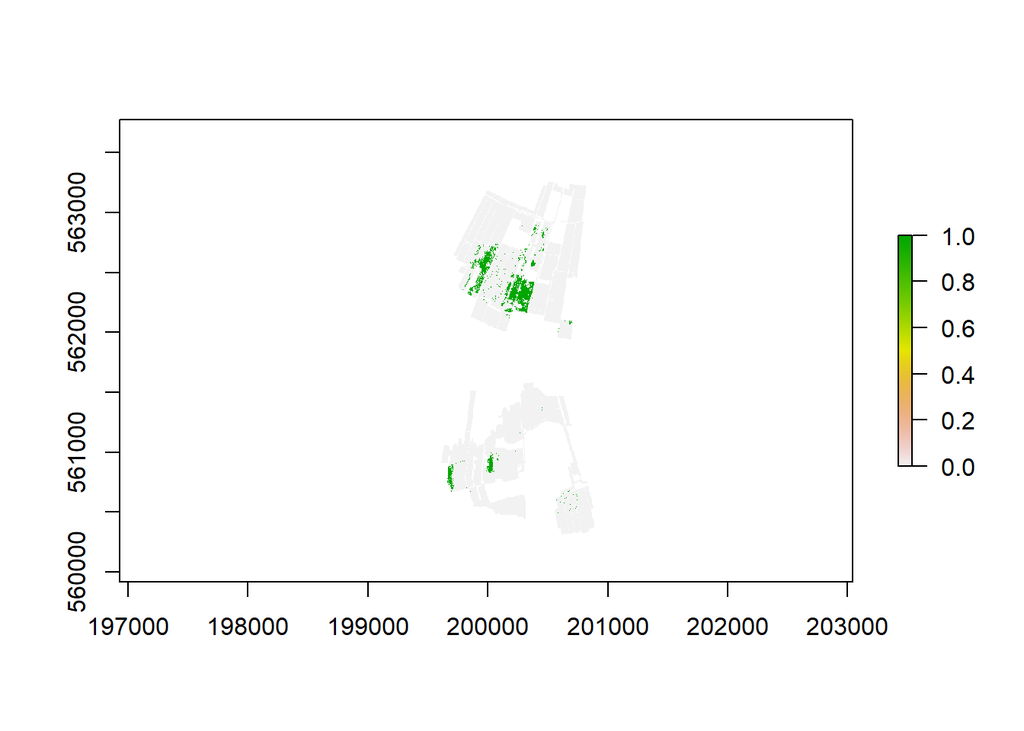

```r
pred <- stats::predict( modFit, df ) %>% as.numeric() - 1
prob <- stats::predict( modFit, df, type = "prob" ) %>% .[,"1"]

corr_pos <- df$Veg=="1" & pred=="1"
corr_neg <- df$Veg=="0" & pred=="0"
false_pos <- df$Veg=="0" & pred=="1"
false_neg <- df$Veg=="1" & pred=="0"
kwal <- rep(0,length(df$Veg))
kwal[corr_pos]  <- 1
kwal[corr_neg]  <- 2
kwal[false_pos] <- -1
kwal[false_neg] <- -2

pred_rast <- stk$Veg
suppressWarnings(pred_rast[] <- NA)

prob_rast <- pred_rast
kwal_rast <- pred_rast

rownrs <- row.names(df) %>% as.numeric()
training_rownrs <- row.names(training) %>% as.numeric()
pred_rast[rownrs] <- pred
proj4string(pred_rast) <- crsAfoort
prob_rast[rownrs] <- prob
proj4string(prob_rast) <- crsAfoort
kwal_rast[rownrs] <- kwal
proj4string(kwal_rast) <- crsAfoort
kwal_rast[training_rownrs] <- 0

plot(pred_rast)
```

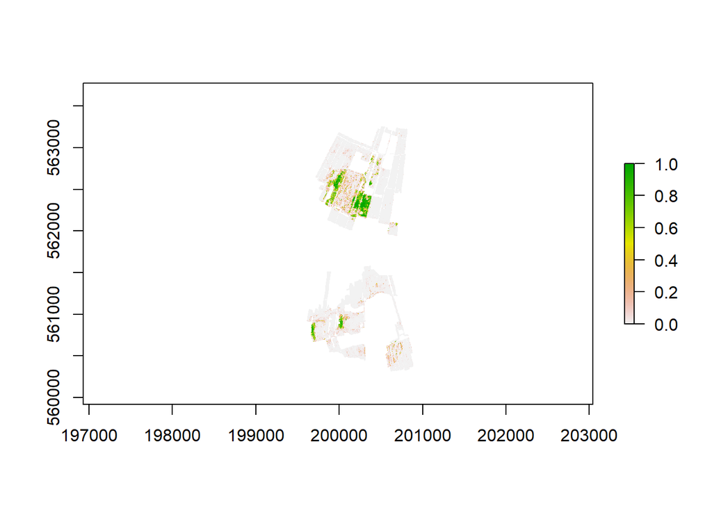

```r
plot(prob_rast)
```

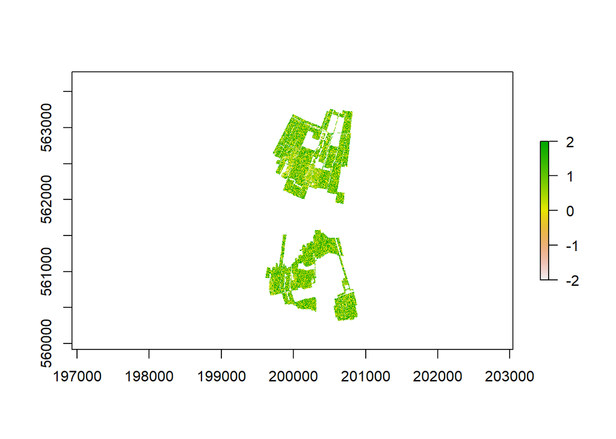

```r
plot(kwal_rast)
```

### Optimaliseer GxG’s in geselecteerd perceel.

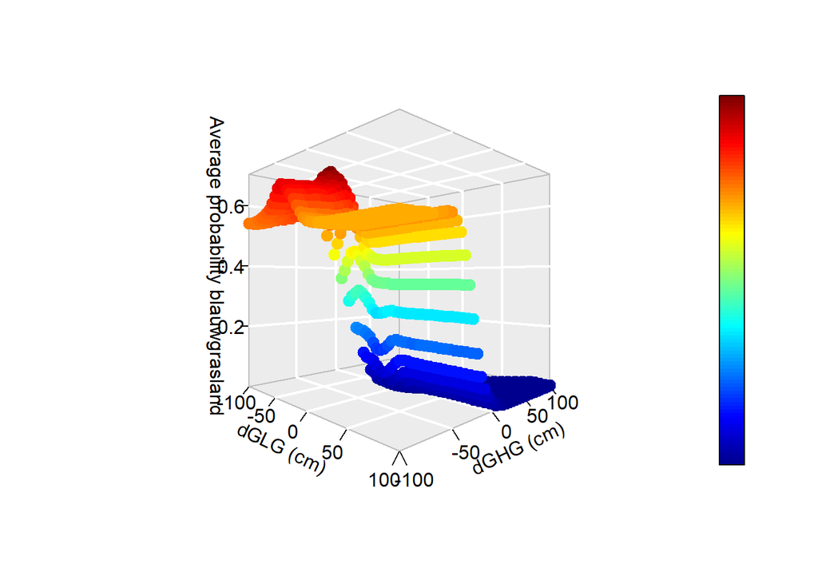

```r
# Knip de gegevens zodat alleen het te optimaliseren perceel erin ligt (scheelt tijd en geheugen).
# Maak een plot van het resultaat (`s3d`) en schrijf dit weg  naar de 'home' directory in het bestand
# 'dGxG - average probability blauwgrasland.png'.
# De verhoging van de GHG is steeds gelijk gesteld aan de verhoging van de GLG (afact=1).
e <- perceel %>% trim() %>% extent()
r <- crop(stk, e)
p <- crop(perceel, e)
dGxG_results <- try_dGxGs(afact = 1, r, modFit, p)
prob <-
  sapply(dGxG_results, function(x) {
    mean_prob(x$prob_rast, p)
  })
x <- get_dGxG(afact = 1)
x <- cbind(x, prob) %>% as.data.frame()
ok <- x$prob != -1
x <- x[ok,]
```

```r
# Selecteer dGxG die de grootste kanst op blauwgrasland geeft.
i <- which.max(x$prob)
max_prob <- max(x$prob, na.rm=TRUE)
x$prob <- NULL
dGxG <- x[i,] %>% as.numeric()
```

De hoogste kans op blauwgrasland is 70% bij een verandering van resp. de GLG en GHG van -40, -50.

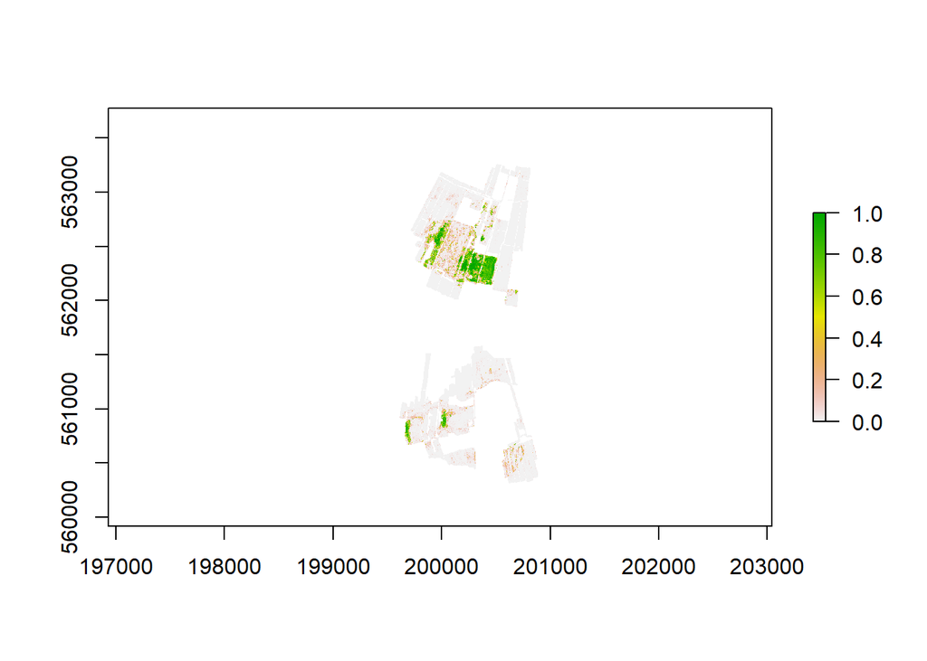

```r
# Maak raster layer met de kansen op blauwgrasland bij optimale GxG's voor geselecteerd perceel; plot dit raster layer
# en schrijf weg  naar de 'home' directory in het bestand 'Probability OptPerceel.tif'.
# Schrijf ook de optimale GHG en GLG raster layers weg naar resp. 'GHG_Optperceel.tif' en 'GLG_Optperceel.tif'.
opt <- dGxG_blauwgrasland(dGxG, stk, modFit, perceel)
plot( opt$prob_rast )
```

Bereken de gemiddelde GHG en GLG (cm-mv) in het perceel na optimalisatie.

```r
GHG_gem_opt_perceel <- mean_prob(opt$stk$GHG, perceel)
GLG_gem_opt_perceel <- mean_prob(opt$stk$GLG, perceel)
```

In het geoptimaliseerde perceel is de gemiddelde GHG -2 (cm-mv). In het geoptimaliseerde perceel is de gemiddelde GLG 53 (cm-mv).